# Tarea 21

#### Convergencia casi segura

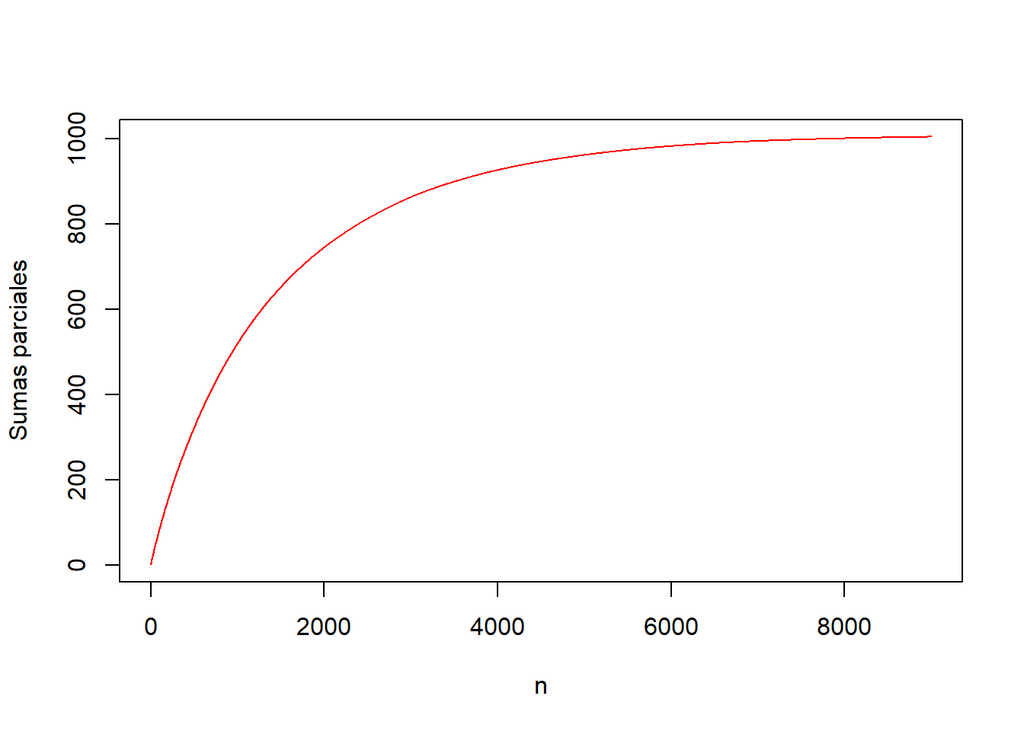

```r
N = 9000
k = 15000
p = 1/2

valores.experimento=matrix(rbinom(N*k,m,p),k,N)

matriz.medias.muestrales = t(apply(valores.experimento,1,calculo.xnbarra))

probabilidades.pn= colSums(abs(matriz.medias.muestrales-(m*p)) > epsilon)/k

plot(1:N,cumsum(probabilidades.pn),xlab=expression(n), ylab="Sumas parciales",col='red', type='l')
```

Debido a las limitaciones de mi maquina, los valores máximos que pude poner para $N$ y para $k$ fueron $N = 9000$ y $k = 15000$. Con valores mayores, cuando intenta procesar los cálculos arroja un error de falta de memoria, lo cual es lógico dada la cantidad de calculos y el tamaño del vector de probabilidades que intenta almacenar. Aun así, se puede observar en el gráfico que las sumas parciales convergen.

### Ejercicio 2

#### Convergencia en probabilidad

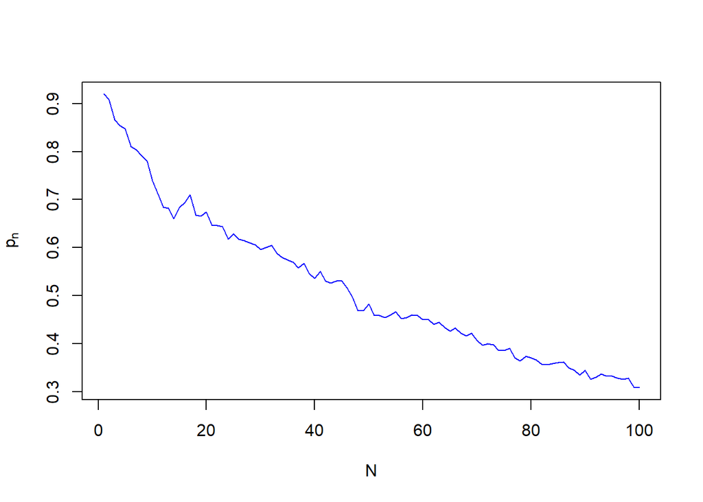

```r
N = 100
k = 500
lambda = 2

valores.experimento=matrix(rexp(N*k,lambda),k,N)

matriz.medias.muestrales = t(apply(valores.experimento,1,calculo.xnbarra))

probabilidades.pn= colSums(abs(matriz.medias.muestrales-(1/lambda)) > epsilon)/k

plot(1:N,probabilidades.pn,type="l",xlab=expression(N),ylab=expression(p[n]),col="blue")
```

Si aumentamos el valor de $\lambda$ veremos una pronta caida de la curva al inicio del tamaño de la muestra, o mejor dicho, para valores bajos del tamaño de la curva.

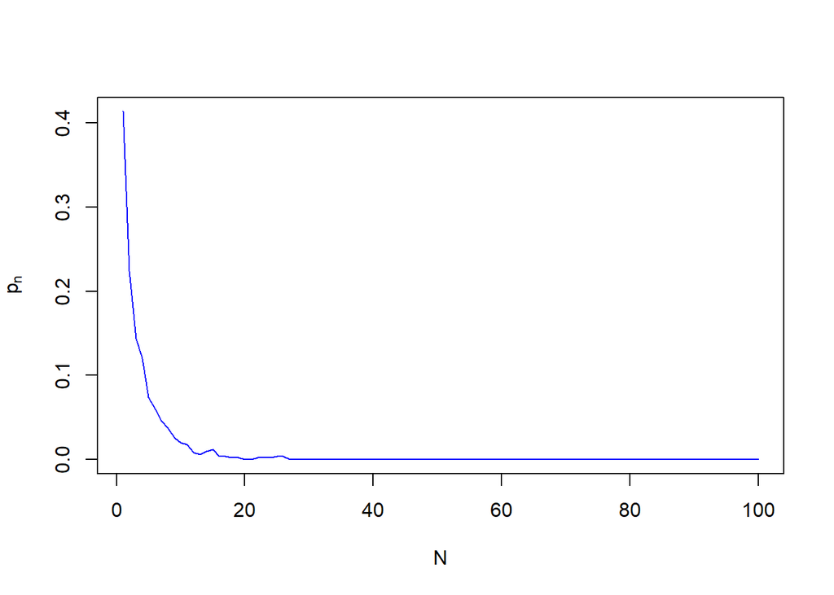

```r
lambda = 15

valores.experimento=matrix(rexp(N*k,lambda),k,N)

matriz.medias.muestrales = t(apply(valores.experimento,1,calculo.xnbarra))

probabilidades.pn= colSums(abs(matriz.medias.muestrales-(1/lambda)) > epsilon)/k

plot(1:N,probabilidades.pn,type="l",xlab=expression(N),ylab=expression(p[n]),col="blue")
```

#### Convergencia casi segura

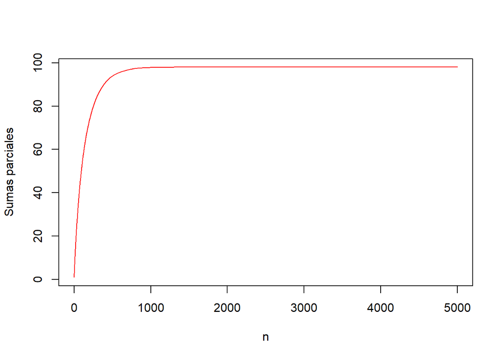

```r
N = 5000
k = 5000
lambda = 2

valores.experimento=matrix(rexp(N*k,lambda),k,N)

matriz.medias.muestrales = t(apply(valores.experimento,1,calculo.xnbarra))

probabilidades.pn= colSums(abs(matriz.medias.muestrales-(1/lambda)) > epsilon)/k

plot(1:N,cumsum(probabilidades.pn),xlab=expression(n), ylab="Sumas parciales",col='red', type='l')
```